# Practical Machine Learning - Course Project

Nigel Weedon

20 November 2015

# Introduction

This document is the final report for the major “Course Project” assignment of Coursera’s Practical Machine Learning from Johns Hopkins University.

The environment used to develop and test the embedded R code was a Toshiba Laptop(32Gb), Windows 7(64bit) and RStudio Version 0.99.467.

GitHub Repository: [Coursera Practical Machine Learning](https://github.com/weedonn/Coursera-Practical-Machine-Learning)  
GitPage: [Course Project Report](http://weedonn.github.io/Coursera-Practical-Machine-Learning/)

# Background

Using devices such as *Jawbone Up*, *Nike FuelBand*, and *Fitbit* it is now possible to collect a large amount of data about personal activity relatively inexpensively. These type of devices are part of the quantified self movement - a group of enthusiasts who take measurements about themselves regularly to improve their health, to find patterns in their behaviour, or because they are tech geeks. One thing that people regularly do is quantify how *much* of a particular activity they do, but they rarely quantify *how well they do it*. In this project, your goal will be to use data from accelerometers on the belt, forearm, arm, and dumbbell of 6 participants. They were asked to perform barbell lifts correctly and incorrectly in 5 different ways. More information is available from the website [here](http://groupware.les.inf.puc-rio.br/har) (see the section on the Weight Lifting Exercise Dataset).

# Methodology

The goal of the project is to predict the manner in which each of the 6 participants, mentioned in the **Background** above, did their exercise.  
This is defined by the target variable “classe” in the training dataset.  
We first explore and analyse the training data provided using the R package/tool rattle(). We also load the training data set into Microsoft Excel to home in on and analyse specific feature or predictor data.  
Based on this analysis, we cleans the data by removing whole columns of NULL data. Depending on the volume of other missing data and their location, we can impute these values and/or only retain **complete.cases**. This is where rows of data are removed if there is any missing data in the row.  
After cleansing the data we look at other techniques to reduce the number of predictors, such as identifying “near-zero-variance” predictors and “variable importance” of each predictor.  
Since the target variable is a categorical with 5 levels (A,B,C,D,E), we choose 2 model algorithms, “Random Forest(rf)” and the clustering algorithm “K-Nearest Neighbour(knn)” to train and compare models.  
We partition the training dataset into 2 sub-sets, training and validation(testing) sets, which are based on a random 70%/30% split. To estimate the out-of-sample error rate we train a randomForest model on a small subset of the training data. We then train each model(rf, knn) using the full training dataset and note the out-of-sample error rate. We then use these models to predict the target variable and note the models predictive accuracy percentage. The model with the highest accuracy and lowest out-of-sample error rate will be used to predict the final submission test data. The accuracy and out-of-sample error rate of the models can then be tuned by iteratively including/excluding data and/or model training parameter changes.  
Because the out-of-sample error rate was initially so low, the creation of additional and/or covariate features was deemed to be unneccessary.

# Data

There were 2 data sets provided for this project, a training data set and a testing data set.  
The training data set is available here: pml-training.csv

The testing data set is available here: pml-testing.csv

The Human Activity Recognition Project at Groupware@LES have been very generous in allowing their data to be used for this assignment.  
The data for this course project comes from this source: [Human Activity Recognition](http://groupware.les.inf.puc-rio.br/har).

# Building the Model

## Setup the environment

```r
## Clear the workspace.
rm(list=ls())
## Load the required packages.
library("caret")
library("rattle")
#rattle()
# Set the random seed.
set.seed(1618)
# Function to generate files with predictions to submit for assignment
pml_write_files = function(x){
        n = length(x)
        for(i in 1:n){
                filename = paste0("problem_id_",i,".txt")
                write.table(x[i],file=filename,quote=FALSE,row.names=FALSE,col.names=FALSE)
        }
}
```

# Data Exploration and Analysis

The initial data analysis was performed via rattle(), which provides a GUI to explore the data and generates a huge number of statistics.  
We look at the data types (identity,categoric,numeric,target), unique values (levels), number and percentage of missing values, skewness of the data in each column and if there are any outliers (mean substantially different to median). This analysis highlighted a huge number of “missing” observations and the occurance of “#DIV/0!” which we also interpret as a missing value.

```r
# R Code courtesy of rattle()
crs$datasetUrl <- "https://d396qusza40orc.cloudfront.net/predmachlearn/pml-training.csv"
crs$dataset <- read.csv(url(crs$datasetUrl), na.strings=c(".", "NA", "", "?", "#DIV/0!"), strip.white=TRUE, encoding="UTF-8")
crs$nobs <- nrow(crs$dataset) # 19622 observations
crs$sample <- crs$train <- sample(nrow(crs$dataset), 0.7*crs$nobs) # 13735 observations
crs$validate <- sample(setdiff(seq_len(nrow(crs$dataset)), crs$train), 0.15*crs$nobs) # 2943 observations
crs$test <- setdiff(setdiff(seq_len(nrow(crs$dataset)), crs$train), crs$validate) # 2944 observations

# The following variable selections have been noted.

crs$input <- c("user_name", "raw_timestamp_part_1", "raw_timestamp_part_2", "cvtd_timestamp",
     "new_window", "num_window", "roll_belt", "pitch_belt",
     "yaw_belt", "total_accel_belt", "kurtosis_roll_belt", "kurtosis_picth_belt",
     "skewness_roll_belt", "skewness_roll_belt.1", "max_roll_belt", "max_picth_belt",
     "max_yaw_belt", "min_roll_belt", "min_pitch_belt", "min_yaw_belt",
     "amplitude_roll_belt", "amplitude_pitch_belt", "amplitude_yaw_belt", "var_total_accel_belt",
     "avg_roll_belt", "stddev_roll_belt", "var_roll_belt", "avg_pitch_belt",
     "stddev_pitch_belt", "var_pitch_belt", "avg_yaw_belt", "stddev_yaw_belt",
     "var_yaw_belt", "gyros_belt_x", "gyros_belt_y", "gyros_belt_z",
     "accel_belt_x", "accel_belt_y", "accel_belt_z", "magnet_belt_x",
     "magnet_belt_y", "magnet_belt_z", "roll_arm", "pitch_arm",
     "yaw_arm", "total_accel_arm", "var_accel_arm", "avg_roll_arm",
     "stddev_roll_arm", "var_roll_arm", "avg_pitch_arm", "stddev_pitch_arm",
     "var_pitch_arm", "avg_yaw_arm", "stddev_yaw_arm", "var_yaw_arm",
     "gyros_arm_x", "gyros_arm_y", "gyros_arm_z", "accel_arm_x",
     "accel_arm_y", "accel_arm_z", "magnet_arm_x", "magnet_arm_y",
     "magnet_arm_z", "kurtosis_roll_arm", "kurtosis_picth_arm", "kurtosis_yaw_arm",
     "skewness_roll_arm", "skewness_pitch_arm", "skewness_yaw_arm", "max_roll_arm",
     "max_picth_arm", "max_yaw_arm", "min_roll_arm", "min_pitch_arm",
     "min_yaw_arm", "amplitude_roll_arm", "amplitude_pitch_arm", "amplitude_yaw_arm",
     "roll_dumbbell", "pitch_dumbbell", "yaw_dumbbell", "kurtosis_roll_dumbbell",
     "kurtosis_picth_dumbbell", "skewness_roll_dumbbell", "skewness_pitch_dumbbell", "max_roll_dumbbell",
     "max_picth_dumbbell", "max_yaw_dumbbell", "min_roll_dumbbell", "min_pitch_dumbbell",
     "min_yaw_dumbbell", "amplitude_roll_dumbbell", "amplitude_pitch_dumbbell", "amplitude_yaw_dumbbell",
     "total_accel_dumbbell", "var_accel_dumbbell", "avg_roll_dumbbell", "stddev_roll_dumbbell",
     "var_roll_dumbbell", "avg_pitch_dumbbell", "stddev_pitch_dumbbell", "var_pitch_dumbbell",
     "avg_yaw_dumbbell", "stddev_yaw_dumbbell", "var_yaw_dumbbell", "gyros_dumbbell_x",
     "gyros_dumbbell_y", "gyros_dumbbell_z", "accel_dumbbell_x", "accel_dumbbell_y",
     "accel_dumbbell_z", "magnet_dumbbell_x", "magnet_dumbbell_y", "magnet_dumbbell_z",
     "roll_forearm", "pitch_forearm", "yaw_forearm", "kurtosis_roll_forearm",
     "kurtosis_picth_forearm", "skewness_roll_forearm", "skewness_pitch_forearm", "max_roll_forearm",
     "max_picth_forearm", "max_yaw_forearm", "min_roll_forearm", "min_pitch_forearm",
     "min_yaw_forearm", "amplitude_roll_forearm", "amplitude_pitch_forearm", "amplitude_yaw_forearm",
     "total_accel_forearm", "var_accel_forearm", "avg_roll_forearm", "stddev_roll_forearm",
     "var_roll_forearm", "avg_pitch_forearm", "stddev_pitch_forearm", "var_pitch_forearm",
     "avg_yaw_forearm", "stddev_yaw_forearm", "var_yaw_forearm", "gyros_forearm_x",
     "gyros_forearm_y", "gyros_forearm_z", "accel_forearm_x", "accel_forearm_y",
     "accel_forearm_z", "magnet_forearm_x", "magnet_forearm_y", "magnet_forearm_z")

crs$numeric <- c("raw_timestamp_part_1", "raw_timestamp_part_2", "num_window", "roll_belt",
     "pitch_belt", "yaw_belt", "total_accel_belt", "max_roll_belt",
     "max_picth_belt", "min_roll_belt", "min_pitch_belt", "amplitude_roll_belt",
     "amplitude_pitch_belt", "var_total_accel_belt", "avg_roll_belt", "stddev_roll_belt",
     "var_roll_belt", "avg_pitch_belt", "stddev_pitch_belt", "var_pitch_belt",
     "avg_yaw_belt", "stddev_yaw_belt", "var_yaw_belt", "gyros_belt_x",
     "gyros_belt_y", "gyros_belt_z", "accel_belt_x", "accel_belt_y",
     "accel_belt_z", "magnet_belt_x", "magnet_belt_y", "magnet_belt_z",
     "roll_arm", "pitch_arm", "yaw_arm", "total_accel_arm",
     "var_accel_arm", "avg_roll_arm", "stddev_roll_arm", "var_roll_arm",
     "avg_pitch_arm", "stddev_pitch_arm", "var_pitch_arm", "avg_yaw_arm",
     "stddev_yaw_arm", "var_yaw_arm", "gyros_arm_x", "gyros_arm_y",
     "gyros_arm_z", "accel_arm_x", "accel_arm_y", "accel_arm_z",
     "magnet_arm_x", "magnet_arm_y", "magnet_arm_z", "max_roll_arm",
     "max_picth_arm", "max_yaw_arm", "min_roll_arm", "min_pitch_arm",
     "min_yaw_arm", "amplitude_roll_arm", "amplitude_pitch_arm", "amplitude_yaw_arm",
     "roll_dumbbell", "pitch_dumbbell", "yaw_dumbbell", "max_roll_dumbbell",
     "max_picth_dumbbell", "min_roll_dumbbell", "min_pitch_dumbbell", "amplitude_roll_dumbbell",
     "amplitude_pitch_dumbbell", "total_accel_dumbbell", "var_accel_dumbbell", "avg_roll_dumbbell",
     "stddev_roll_dumbbell", "var_roll_dumbbell", "avg_pitch_dumbbell", "stddev_pitch_dumbbell",
     "var_pitch_dumbbell", "avg_yaw_dumbbell", "stddev_yaw_dumbbell", "var_yaw_dumbbell",
     "gyros_dumbbell_x", "gyros_dumbbell_y", "gyros_dumbbell_z", "accel_dumbbell_x",
     "accel_dumbbell_y", "accel_dumbbell_z", "magnet_dumbbell_x", "magnet_dumbbell_y",
     "magnet_dumbbell_z", "roll_forearm", "pitch_forearm", "yaw_forearm",
     "max_roll_forearm", "max_picth_forearm", "min_roll_forearm", "min_pitch_forearm",
     "amplitude_roll_forearm", "amplitude_pitch_forearm", "total_accel_forearm", "var_accel_forearm",
     "avg_roll_forearm", "stddev_roll_forearm", "var_roll_forearm", "avg_pitch_forearm",
     "stddev_pitch_forearm", "var_pitch_forearm", "avg_yaw_forearm", "stddev_yaw_forearm",
     "var_yaw_forearm", "gyros_forearm_x", "gyros_forearm_y", "gyros_forearm_z",
     "accel_forearm_x", "accel_forearm_y", "accel_forearm_z", "magnet_forearm_x",
     "magnet_forearm_y", "magnet_forearm_z")

crs$categoric <- c("user_name", "cvtd_timestamp", "new_window", "kurtosis_roll_belt",
     "kurtosis_picth_belt", "skewness_roll_belt", "skewness_roll_belt.1", "max_yaw_belt",
     "min_yaw_belt", "amplitude_yaw_belt", "kurtosis_roll_arm", "kurtosis_picth_arm",
     "kurtosis_yaw_arm", "skewness_roll_arm", "skewness_pitch_arm", "skewness_yaw_arm",
     "kurtosis_roll_dumbbell", "kurtosis_picth_dumbbell", "skewness_roll_dumbbell", "skewness_pitch_dumbbell",
     "max_yaw_dumbbell", "min_yaw_dumbbell", "amplitude_yaw_dumbbell", "kurtosis_roll_forearm",
     "kurtosis_picth_forearm", "skewness_roll_forearm", "skewness_pitch_forearm", "max_yaw_forearm",
     "min_yaw_forearm", "amplitude_yaw_forearm")

crs$target  <- "classe"
crs$risk    <- NULL
crs$ident   <- "X"
crs$ignore  <- c("kurtosis_yaw_belt", "skewness_yaw_belt", "kurtosis_yaw_dumbbell", "skewness_yaw_dumbbell", "kurtosis_yaw_forearm", "skewness_yaw_forearm")
crs$weights <- NULL
```

## Summary of the Dataset

```r
# The 'Hmisc' package provides the 'contents' function.
library(Hmisc, quietly=TRUE)
# Obtain a summary of the dataset.

contents(crs$dataset[crs$sample, c(crs$input, crs$risk, crs$target)])
```

```
##
## Data frame:crs$dataset[crs$sample, c(crs$input, crs$risk, crs$target)]   13735 observations and 153 variables    Maximum # NAs:13518
##
##
##                          Levels Storage   NAs
## user_name                     6 integer     0
## raw_timestamp_part_1            integer     0
## raw_timestamp_part_2            integer     0
## cvtd_timestamp               20 integer     0
## new_window                    2 integer     0
## num_window                      integer     0
## roll_belt                        double     0
## pitch_belt                       double     0
## yaw_belt                         double     0
## total_accel_belt                integer     0
## kurtosis_roll_belt               double 13464
## kurtosis_picth_belt              double 13481
## skewness_roll_belt               double 13464
## skewness_roll_belt.1             double 13481
## max_roll_belt                    double 13458
## max_picth_belt                  integer 13458
## max_yaw_belt                     double 13464
## min_roll_belt                    double 13458
## min_pitch_belt                  integer 13458
## min_yaw_belt                     double 13464
## amplitude_roll_belt              double 13458
## amplitude_pitch_belt            integer 13458
## amplitude_yaw_belt               double 13464
## var_total_accel_belt             double 13458
## avg_roll_belt                    double 13458
## stddev_roll_belt                 double 13458
## var_roll_belt                    double 13458
## avg_pitch_belt                   double 13458
## stddev_pitch_belt                double 13458
## var_pitch_belt                   double 13458
## avg_yaw_belt                     double 13458
## stddev_yaw_belt                  double 13458
## var_yaw_belt                     double 13458
## gyros_belt_x                     double     0
## gyros_belt_y                     double     0
```

[output cut: 121 more lines]

```
## +--------------+--------------------------------------------------+
## |user_name     |adelmo,carlitos,charles,eurico,jeremy,pedro       |
## +--------------+--------------------------------------------------+
## |cvtd_timestamp|02/12/2011 13:32,02/12/2011 13:33,02/12/2011 13:34|
## |              |02/12/2011 13:35,02/12/2011 14:56,02/12/2011 14:57|
## |              |02/12/2011 14:58,02/12/2011 14:59,05/12/2011 11:23|
## |              |05/12/2011 11:24,05/12/2011 11:25,05/12/2011 14:22|
## |              |05/12/2011 14:23,05/12/2011 14:24,28/11/2011 14:13|
## |              |28/11/2011 14:14,28/11/2011 14:15,30/11/2011 17:10|
## |              |30/11/2011 17:11,30/11/2011 17:12                 |
## +--------------+--------------------------------------------------+
## |new_window    |no,yes                                            |
## +--------------+--------------------------------------------------+
## |classe        |A,B,C,D,E                                         |
## +--------------+--------------------------------------------------+
```

```r
#summary(crs$dataset[crs$sample, c(crs$input, crs$risk, crs$target)])
```

## Skewness of the Dataset

NOTE: Skewness for each numeric variable of the dataset.  
Positive means the right tail is longer.

```r
# The 'skewness' package provides the 'fBasics' function.
library(fBasics, quietly=TRUE)
# Summarise the skewness of the numeric data.

skewness(crs$dataset[crs$sample, c(crs$input, crs$risk, crs$target)][,c(2:3, 6:10, 15:16, 18:19, 21:22, 24:65, 72:83, 88:89, 91:92, 94:95, 97:119, 124:125, 127:128, 130:131, 133:152)], na.rm=TRUE)
```

```
##     raw_timestamp_part_1     raw_timestamp_part_2               num_window
##            -1.580396e-01             4.678170e-03             2.080048e-02
##                roll_belt               pitch_belt                 yaw_belt
##            -7.051005e-03            -1.014926e+00             9.171217e-01
##         total_accel_belt            max_roll_belt           max_picth_belt
##             4.058959e-02             8.838402e-01             5.396415e-02
##            min_roll_belt           min_pitch_belt      amplitude_roll_belt
##             8.816877e-01            -1.188343e-01             1.145698e+01
##     amplitude_pitch_belt     var_total_accel_belt            avg_roll_belt
##             2.050086e+00             3.760269e+00            -9.616406e-02
##         stddev_roll_belt            var_roll_belt           avg_pitch_belt
##             2.555071e+00             4.220248e+00            -1.061007e+00
##        stddev_pitch_belt           var_pitch_belt             avg_yaw_belt
##             2.118180e+00             4.310247e+00             9.011835e-01
##          stddev_yaw_belt             var_yaw_belt             gyros_belt_x
##             1.239809e+01             1.413915e+01            -5.489531e-01
##             gyros_belt_y             gyros_belt_z             accel_belt_x
##            -2.529266e-02             2.203947e-01             9.894647e-01
##             accel_belt_y             accel_belt_z            magnet_belt_x
##             1.570724e-01             1.306348e-02             1.447357e+00
##            magnet_belt_y            magnet_belt_z                 roll_arm
##            -2.253333e+00            -3.005209e-02            -1.792004e-01
##                pitch_arm                  yaw_arm          total_accel_arm
##             1.983045e-01            -9.434383e-02             7.054934e-02
##            var_accel_arm             avg_roll_arm          stddev_roll_arm
##             1.408065e+00             8.011436e-02             5.664901e+00
##             var_roll_arm            avg_pitch_arm         stddev_pitch_arm
##             1.059996e+01             2.267087e-01             9.599868e-01
##            var_pitch_arm              avg_yaw_arm           stddev_yaw_arm
##             2.553959e+00            -7.503645e-02             2.360968e+00
##              var_yaw_arm              gyros_arm_x              gyros_arm_y
##             7.666036e+00            -2.853610e-01             1.430610e-01
##              gyros_arm_z              accel_arm_x              accel_arm_y
##            -1.871479e-01             3.409763e-01             8.837360e-02
##              accel_arm_z             magnet_arm_x             magnet_arm_y
##            -8.625484e-01            -1.472914e-01            -4.763198e-01
##             magnet_arm_z             max_roll_arm            max_picth_arm
##            -1.154612e+00             3.294905e-01            -1.544709e-01
##              max_yaw_arm             min_roll_arm            min_pitch_arm
##             6.105414e-02             2.023569e-01            -2.263161e-02
```

[output cut: 27 more lines]

```
##             4.054186e-01             1.211861e+00             6.097221e-01
##      total_accel_forearm        var_accel_forearm         avg_roll_forearm
##            -5.858018e-01             1.300235e+00            -1.860142e-01
##      stddev_roll_forearm         var_roll_forearm        avg_pitch_forearm
##             1.186357e+00             1.583957e+00            -8.793283e-01
##     stddev_pitch_forearm        var_pitch_forearm          avg_yaw_forearm
##             1.321635e+00             3.188424e+00            -1.351470e-01
##       stddev_yaw_forearm          var_yaw_forearm          gyros_forearm_x
##             9.376628e-01             1.660301e+00            -2.713698e+00
##          gyros_forearm_y          gyros_forearm_z          accel_forearm_x
##             5.456462e+01             1.022027e+02            -2.287852e-01
##          accel_forearm_y          accel_forearm_z         magnet_forearm_x
##            -6.487995e-01             4.360518e-01             6.426217e-01
##         magnet_forearm_y         magnet_forearm_z
##            -7.467681e-01            -1.220267e+00
```

```r
rm(crs)
```

## Load the Training and Testing datasets

```r
pml_training_Url <- "https://d396qusza40orc.cloudfront.net/predmachlearn/pml-training.csv"
pml_training <- read.csv(url(pml_training_Url), na.strings=c("NA","#DIV/0!",""))
# Remove the first 7 columns which contain Identity, Date/Time and Categorical features, which may not be predictive.
pml_training <- pml_training[, -c(1:7)]
# Discard the columns where there is < 95% observations, based on percentage missing from data analysis.
sum(colSums(!is.na(pml_training)) < nrow(pml_training) * 0.95) #columns with more than 95% data missing
```

```
## [1] 100
```

```r
cols2Keep <- c(colSums(!is.na(pml_training)) >= nrow(pml_training) * 0.95)
pml_training   <-  pml_training[,cols2Keep]
```

## Identify “near-zero-variance” predictors.

After removing columns with a large percentage of null data, there were no near-zero-variance columns identified for removal.

```r
# These predictors may have an undue influence on the model and should be eliminated prior to modeling.
nzv2Remove <- nearZeroVar(pml_training, saveMetrics= TRUE)
nzv2Remove
```

```
##                      freqRatio percentUnique zeroVar   nzv
## roll_belt             1.101904     6.7781062   FALSE FALSE
## pitch_belt            1.036082     9.3772296   FALSE FALSE
## yaw_belt              1.058480     9.9734991   FALSE FALSE
## total_accel_belt      1.063160     0.1477933   FALSE FALSE
## gyros_belt_x          1.058651     0.7134849   FALSE FALSE
## gyros_belt_y          1.144000     0.3516461   FALSE FALSE
## gyros_belt_z          1.066214     0.8612782   FALSE FALSE
## accel_belt_x          1.055412     0.8357966   FALSE FALSE
## accel_belt_y          1.113725     0.7287738   FALSE FALSE
## accel_belt_z          1.078767     1.5237998   FALSE FALSE
## magnet_belt_x         1.090141     1.6664968   FALSE FALSE
## magnet_belt_y         1.099688     1.5187035   FALSE FALSE
## magnet_belt_z         1.006369     2.3290184   FALSE FALSE
## roll_arm             52.338462    13.5256345   FALSE FALSE
## pitch_arm            87.256410    15.7323412   FALSE FALSE
## yaw_arm              33.029126    14.6570176   FALSE FALSE
## total_accel_arm       1.024526     0.3363572   FALSE FALSE
## gyros_arm_x           1.015504     3.2769341   FALSE FALSE
## gyros_arm_y           1.454369     1.9162165   FALSE FALSE
## gyros_arm_z           1.110687     1.2638875   FALSE FALSE
## accel_arm_x           1.017341     3.9598410   FALSE FALSE
## accel_arm_y           1.140187     2.7367241   FALSE FALSE
## accel_arm_z           1.128000     4.0362858   FALSE FALSE
## magnet_arm_x          1.000000     6.8239731   FALSE FALSE
## magnet_arm_y          1.056818     4.4439914   FALSE FALSE
## magnet_arm_z          1.036364     6.4468454   FALSE FALSE
## roll_dumbbell         1.022388    84.2065029   FALSE FALSE
## pitch_dumbbell        2.277372    81.7449801   FALSE FALSE
## yaw_dumbbell          1.132231    83.4828254   FALSE FALSE
## total_accel_dumbbell  1.072634     0.2191418   FALSE FALSE
## gyros_dumbbell_x      1.003268     1.2282132   FALSE FALSE
## gyros_dumbbell_y      1.264957     1.4167771   FALSE FALSE
## gyros_dumbbell_z      1.060100     1.0498420   FALSE FALSE
## accel_dumbbell_x      1.018018     2.1659362   FALSE FALSE
## accel_dumbbell_y      1.053061     2.3748853   FALSE FALSE
## accel_dumbbell_z      1.133333     2.0894914   FALSE FALSE
## magnet_dumbbell_x     1.098266     5.7486495   FALSE FALSE
## magnet_dumbbell_y     1.197740     4.3012945   FALSE FALSE
## magnet_dumbbell_z     1.020833     3.4451126   FALSE FALSE
## roll_forearm         11.589286    11.0895933   FALSE FALSE
## pitch_forearm        65.983051    14.8557741   FALSE FALSE
## yaw_forearm          15.322835    10.1467740   FALSE FALSE
## total_accel_forearm   1.128928     0.3567424   FALSE FALSE
## gyros_forearm_x       1.059273     1.5187035   FALSE FALSE
## gyros_forearm_y       1.036554     3.7763735   FALSE FALSE
## gyros_forearm_z       1.122917     1.5645704   FALSE FALSE
## accel_forearm_x       1.126437     4.0464784   FALSE FALSE
## accel_forearm_y       1.059406     5.1116094   FALSE FALSE
## accel_forearm_z       1.006250     2.9558659   FALSE FALSE
## magnet_forearm_x      1.012346     7.7667924   FALSE FALSE
## magnet_forearm_y      1.246914     9.5403119   FALSE FALSE
## magnet_forearm_z      1.000000     8.5771073   FALSE FALSE
## classe                1.469581     0.0254816   FALSE FALSE
```

```r
# Identify and remove "near-zero-variance" predictors.
#pml_training <- pml_training[, nzv2Remove$nzv==FALSE]
```

## Apply the same data cleansing to the testing data set

```r
pml_testing_Url <- "https://d396qusza40orc.cloudfront.net/predmachlearn/pml-testing.csv"
pml_testing <- read.csv(url(pml_testing_Url), na.strings=c("NA","#DIV/0!",""))
# Remove the first 7 columns which contain Identity, Date/Time and Categorical features, which may not be predictive.
pml_testing <- pml_testing[ , -c(1:7)]
# Discard the columns where there is < 95% observations
pml_testing <- pml_testing[,cols2Keep]
# Identify and remove "near-zero-variance" predictors.
#pml_testing <- pml_testing[, nzv2Remove$nzv==FALSE]
```

## Verify column names

```r
# Verify that the column names in the training and test sets are identical, excluding the classe and problem_id columns.
colnames(pml_training)
```

```
##  [1] "roll_belt"            "pitch_belt"           "yaw_belt"
##  [4] "total_accel_belt"     "gyros_belt_x"         "gyros_belt_y"
##  [7] "gyros_belt_z"         "accel_belt_x"         "accel_belt_y"
## [10] "accel_belt_z"         "magnet_belt_x"        "magnet_belt_y"
## [13] "magnet_belt_z"        "roll_arm"             "pitch_arm"
## [16] "yaw_arm"              "total_accel_arm"      "gyros_arm_x"
## [19] "gyros_arm_y"          "gyros_arm_z"          "accel_arm_x"
## [22] "accel_arm_y"          "accel_arm_z"          "magnet_arm_x"
## [25] "magnet_arm_y"         "magnet_arm_z"         "roll_dumbbell"
## [28] "pitch_dumbbell"       "yaw_dumbbell"         "total_accel_dumbbell"
## [31] "gyros_dumbbell_x"     "gyros_dumbbell_y"     "gyros_dumbbell_z"
## [34] "accel_dumbbell_x"     "accel_dumbbell_y"     "accel_dumbbell_z"
## [37] "magnet_dumbbell_x"    "magnet_dumbbell_y"    "magnet_dumbbell_z"
## [40] "roll_forearm"         "pitch_forearm"        "yaw_forearm"
## [43] "total_accel_forearm"  "gyros_forearm_x"      "gyros_forearm_y"
## [46] "gyros_forearm_z"      "accel_forearm_x"      "accel_forearm_y"
## [49] "accel_forearm_z"      "magnet_forearm_x"     "magnet_forearm_y"
## [52] "magnet_forearm_z"     "classe"
```

```r
colnames(pml_testing)
```

```
##  [1] "roll_belt"            "pitch_belt"           "yaw_belt"
##  [4] "total_accel_belt"     "gyros_belt_x"         "gyros_belt_y"
##  [7] "gyros_belt_z"         "accel_belt_x"         "accel_belt_y"
## [10] "accel_belt_z"         "magnet_belt_x"        "magnet_belt_y"
## [13] "magnet_belt_z"        "roll_arm"             "pitch_arm"
## [16] "yaw_arm"              "total_accel_arm"      "gyros_arm_x"
## [19] "gyros_arm_y"          "gyros_arm_z"          "accel_arm_x"
## [22] "accel_arm_y"          "accel_arm_z"          "magnet_arm_x"
## [25] "magnet_arm_y"         "magnet_arm_z"         "roll_dumbbell"
## [28] "pitch_dumbbell"       "yaw_dumbbell"         "total_accel_dumbbell"
## [31] "gyros_dumbbell_x"     "gyros_dumbbell_y"     "gyros_dumbbell_z"
## [34] "accel_dumbbell_x"     "accel_dumbbell_y"     "accel_dumbbell_z"
## [37] "magnet_dumbbell_x"    "magnet_dumbbell_y"    "magnet_dumbbell_z"
## [40] "roll_forearm"         "pitch_forearm"        "yaw_forearm"
## [43] "total_accel_forearm"  "gyros_forearm_x"      "gyros_forearm_y"
## [46] "gyros_forearm_z"      "accel_forearm_x"      "accel_forearm_y"
## [49] "accel_forearm_z"      "magnet_forearm_x"     "magnet_forearm_y"
## [52] "magnet_forearm_z"     "problem_id"
```

## Partitioning Training data set

```r
# Partitioning the Training data set into two data sets, 70% for training, 30% for validation(testing)
inTrain <- createDataPartition(pml_training$classe, p=0.7, list=FALSE)
training <- pml_training[inTrain, ]
testing <- pml_training[-inTrain, ]
```

## Estimate Out-of-Sample Error

We can use a small sample of the training data set to estimate the expected out-of-sample error.  
The randomForest algorithm performs inherent Cross Validation, but we explicitly specify Cross Validation(cv) to calculate an estimate for the out-of-sample error. This sample gives an OOB estimate of error rate of 4.25%.  
As a rule of thumb, the more data we train with the better the predictive accuracy of the model.  
So we would expect that training a model on the full training data set will produce an Out-of-Sample error rate substantially better than 4.25%.

```r
# Partioning the training data set again into a 20% sample data set to estimate the OOB of the final model.
inSample <- createDataPartition(training$classe, p=0.2, list=FALSE)
OOBtraining <- training[inSample, ]
rfOOBModel <- train(OOBtraining$classe ~ ., method="rf", data=OOBtraining,  trControl=trainControl(method="cv"), prox=TRUE, allowParallel=TRUE, importance = TRUE)
# Output of randomForest sample model
rfOOBModel
```

```
## Random Forest
##
## 2750 samples
##   52 predictor
##    5 classes: 'A', 'B', 'C', 'D', 'E'
##
## No pre-processing
## Resampling: Cross-Validated (10 fold)
## Summary of sample sizes: 2476, 2475, 2475, 2474, 2475, 2475, ...
## Resampling results across tuning parameters:
##
##   mtry  Accuracy   Kappa      Accuracy SD  Kappa SD
##    2    0.9487429  0.9350863  0.01797000   0.02280518
##   27    0.9560038  0.9443102  0.01299621   0.01647048
##   52    0.9458126  0.9314306  0.01714798   0.02173988
##
## Accuracy was used to select the optimal model using  the largest value.
## The final value used for the model was mtry = 27.
```

```r
rfOOBModel$finalModel
```

```
##
## Call:
##  randomForest(x = x, y = y, mtry = param$mtry, importance = TRUE,      proximity = TRUE, allowParallel = TRUE)
##                Type of random forest: classification
##                      Number of trees: 500
## No. of variables tried at each split: 27
##
##         OOB estimate of  error rate: 4.25%
## Confusion matrix:
##     A   B   C   D   E class.error
## A 772   5   2   1   2  0.01278772
## B  25 489  13   3   2  0.08082707
## C   0  18 455   7   0  0.05208333
## D   0   0  16 433   2  0.03991131
## E   0   9   7   5 484  0.04158416
```

## Variable Importance Analysis of Random Forest Model

The Variable Importance plots show the top 15 features.

```r
rfImportance <- varImp(rfOOBModel,scale=FALSE) # for train(method="rf")
print(rfImportance$importance)
```

```
##                              A         B         C         D         E
## roll_belt            48.058320 51.576877 48.329721 48.570560 57.776581
## pitch_belt           20.631131 46.247188 26.659745 25.077204 19.678655
## yaw_belt             38.417763 32.062996 30.417319 34.083490 23.466649
## total_accel_belt      8.158503  9.931681  6.604754  8.715915  7.960173
## gyros_belt_x          8.803049  5.609241 13.315821  8.334280  3.785731
## gyros_belt_y          6.753797  8.027465 13.872299  9.175041  6.002334
## gyros_belt_z         15.384407 15.212268 18.331194 15.932987 19.761073
## accel_belt_x          8.336716 11.830943  9.970200  7.268880  7.133508
## accel_belt_y          7.436138  7.518875  7.724179  8.423088  7.872109
## accel_belt_z         13.270922 14.898593 12.430765 16.859871 10.749455
## magnet_belt_x        10.951292 16.420981 19.733755 15.266829 12.512784
## magnet_belt_y        18.676262 26.336843 19.965756 23.008515 22.794546
## magnet_belt_z        18.069116 21.036576 18.258643 22.139716 18.711693
## roll_arm             12.772879 17.406504 14.369439 16.825890 10.767129
## pitch_arm             7.461712 13.010900  7.816850 10.717368 11.029009
## yaw_arm              20.557900 10.663049 16.013506 16.104716  8.847114
## total_accel_arm       9.416422 10.654236  9.737070 11.462065 10.176018
## gyros_arm_x          11.769471 11.714044  6.560275 11.401428  6.511284
## gyros_arm_y          11.725659 12.667024  6.473430 15.134048  5.165168
## gyros_arm_z           6.386757  6.109279  3.505108  7.150324  6.270315
## accel_arm_x           9.040621 12.663677 13.921410 16.108870 10.502057
## accel_arm_y          10.058355 13.005106  7.961425 11.211712  6.880073
## accel_arm_z           9.010242 11.738015 10.727284 12.618375  9.998422
## magnet_arm_x          9.729852  9.832950 10.502455 13.421749  9.235911
## magnet_arm_y          8.712279 12.935757 12.478990 18.313253 13.421082
## magnet_arm_z         16.353982 13.254851 12.370100  8.108947  8.138063
## roll_dumbbell        26.826870 30.437160 30.567730 30.317661 28.578457
## pitch_dumbbell       12.035072 15.247784 13.465507 10.531673 10.659000
## yaw_dumbbell         12.838916 18.323660 14.359049 18.000117 15.102686
## total_accel_dumbbell 16.090779 20.181859 15.221266 20.668274 21.322064
## gyros_dumbbell_x      8.956554 13.035505 16.310893 10.889430 10.887034
## gyros_dumbbell_y     20.838595 11.517087 17.136317 14.892642  9.727035
## gyros_dumbbell_z     11.767694  9.027453 11.590297  9.486942  7.812667
## accel_dumbbell_x     10.034009 14.032327 12.097045 12.594994 11.857252
## accel_dumbbell_y     25.307311 25.340038 31.679313 22.584459 23.071346
## accel_dumbbell_z     19.772019 20.301686 14.974252 18.501197 21.117797
## magnet_dumbbell_x    21.283088 19.100968 23.047121 22.559744 18.270301
## magnet_dumbbell_y    34.004426 29.444893 33.822725 31.138773 25.003166
## magnet_dumbbell_z    52.326873 38.389791 59.756752 42.520670 31.769050
## roll_forearm         29.483635 22.083813 21.647342 21.000161 19.140277
## pitch_forearm        41.222100 39.533267 43.340077 43.963236 33.722819
## yaw_forearm          10.783258 10.409014 10.622340 12.144054  9.089269
## total_accel_forearm   9.385958  9.505651  8.977813  9.799085  6.746529
## gyros_forearm_x       8.146405  3.587944  8.399814  7.451562  4.558560
## gyros_forearm_y       9.320983 13.602669  9.953125  8.160434  6.248608
## gyros_forearm_z       7.229497  8.633220  8.002453  5.802758  6.049166
## accel_forearm_x      12.436637 17.545357 16.775034 21.841306 15.790983
## accel_forearm_y      10.429045  7.515336 10.996257  8.952242  8.588539
## accel_forearm_z      16.597565 12.437359 13.486894 15.035274 14.676150
## magnet_forearm_x     12.921274 12.070924 11.471621 13.099047 13.344497
## magnet_forearm_y     13.317222 12.920145 12.816790 13.094010 12.617585
## magnet_forearm_z     17.535199 13.934318 15.322420 17.431930 13.899900
```

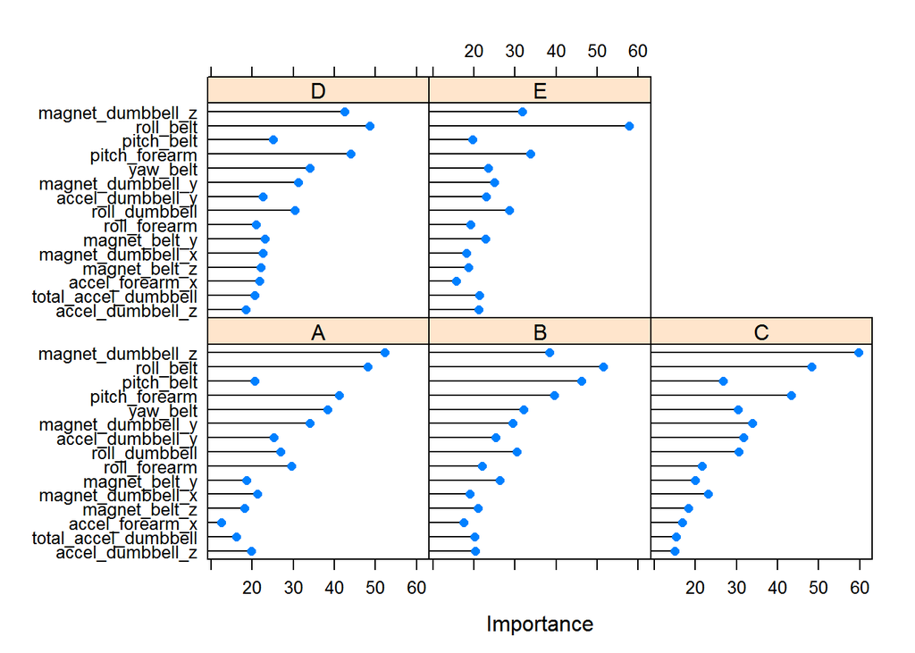

```r
plot(rfImportance, top = 15)
```

## Train the randomForest model - Cross Validation

Now we train a model on the full training data set.  
We found that in previous model training runs that preprocessing the data to normalise the data(preProcess = c(“center”,“scale”)) did not affect the accuracy of the final model. Also repeated cross-validation affected the number of variables per level(mtry) used, but again this did not substantially affect the accuracy of the final model.

```r
randomForestModel <- train(training$classe ~ ., method="rf", data=training,  trControl=trainControl(method="cv"), prox=TRUE, allowParallel=TRUE, importance = TRUE)
# Output of randomForest trained model
randomForestModel
```

```
## Random Forest
##
## 13737 samples
##    52 predictor
##     5 classes: 'A', 'B', 'C', 'D', 'E'
##
## No pre-processing
## Resampling: Cross-Validated (10 fold)
## Summary of sample sizes: 12362, 12364, 12363, 12363, 12361, 12364, ...
## Resampling results across tuning parameters:
##
##   mtry  Accuracy   Kappa      Accuracy SD  Kappa SD
##    2    0.9917015  0.9895014  0.003168503  0.004009350
##   27    0.9914103  0.9891335  0.001964999  0.002485678
##   52    0.9840585  0.9798325  0.003885040  0.004915979
##
## Accuracy was used to select the optimal model using  the largest value.
## The final value used for the model was mtry = 2.
```

```r
# Output of randomForest last model
randomForestModel$finalModel
```

```
##
## Call:
##  randomForest(x = x, y = y, mtry = param$mtry, importance = TRUE,      proximity = TRUE, allowParallel = TRUE)
##                Type of random forest: classification
##                      Number of trees: 500
## No. of variables tried at each split: 2
##
##         OOB estimate of  error rate: 0.68%
## Confusion matrix:
##      A    B    C    D    E  class.error
## A 3903    3    0    0    0 0.0007680492
## B   14 2635    9    0    0 0.0086531226
## C    0   16 2379    1    0 0.0070951586
## D    0    0   41 2208    3 0.0195381883
## E    0    0    0    7 2518 0.0027722772
```

```r
randomForestPredict <- predict(randomForestModel,testing)
randomForestConfMatrix <- confusionMatrix(randomForestPredict, testing$classe)
randomForestConfMatrix
```

```
## Confusion Matrix and Statistics
##
##           Reference
## Prediction    A    B    C    D    E
##          A 1674    6    0    0    0
##          B    0 1132    5    0    0
##          C    0    1 1021   19    0
##          D    0    0    0  945    2
##          E    0    0    0    0 1080
##
## Overall Statistics
##
##                Accuracy : 0.9944
##                  95% CI : (0.9921, 0.9961)
##     No Information Rate : 0.2845
##     P-Value [Acc > NIR] : < 2.2e-16
##
##                   Kappa : 0.9929
##  Mcnemar's Test P-Value : NA
##
## Statistics by Class:
##
##                      Class: A Class: B Class: C Class: D Class: E
## Sensitivity            1.0000   0.9939   0.9951   0.9803   0.9982
## Specificity            0.9986   0.9989   0.9959   0.9996   1.0000
## Pos Pred Value         0.9964   0.9956   0.9808   0.9979   1.0000
## Neg Pred Value         1.0000   0.9985   0.9990   0.9962   0.9996
## Prevalence             0.2845   0.1935   0.1743   0.1638   0.1839
## Detection Rate         0.2845   0.1924   0.1735   0.1606   0.1835
## Detection Prevalence   0.2855   0.1932   0.1769   0.1609   0.1835
## Balanced Accuracy      0.9993   0.9964   0.9955   0.9899   0.9991
```

## Train the K-Nearest Neighbour Model - Cross Validation

In the K-Nearest Neighbour algorithm specify Cross Validation in the trainControl parameter to calculate the out-of-sample error. In this case Resampling: Cross-Validated (10 fold).  
We also pre-process the data (“center”,“scale”) to normalise the data.

```r
# K-Nearest Neighbour Analysis(knn)
# knn requires variables to be normalized or scaled.
KNNctrl = trainControl(method="cv")
KNNmod = train(training$classe ~ ., data=training, method = "knn", trControl = KNNctrl, preProcess = c("center","scale"))
# Output of knn trained model
KNNmod
```

```
## k-Nearest Neighbors
##
## 13737 samples
##    52 predictor
##     5 classes: 'A', 'B', 'C', 'D', 'E'
##
## Pre-processing: centered (52), scaled (52)
## Resampling: Cross-Validated (10 fold)
## Summary of sample sizes: 12363, 12364, 12363, 12363, 12363, 12363, ...
## Resampling results across tuning parameters:
##
##   k  Accuracy   Kappa      Accuracy SD  Kappa SD
##   5  0.9592332  0.9484263  0.005892270  0.007432125
##   7  0.9472219  0.9332177  0.005924549  0.007481698
##   9  0.9357195  0.9186593  0.005982431  0.007568887
##
## Accuracy was used to select the optimal model using  the largest value.
## The final value used for the model was k = 5.
```

Plot Number of Neighbours Vs accuracy  
Plotting yields the Number of Neighbours Vs accuracy, based on the cross validation.

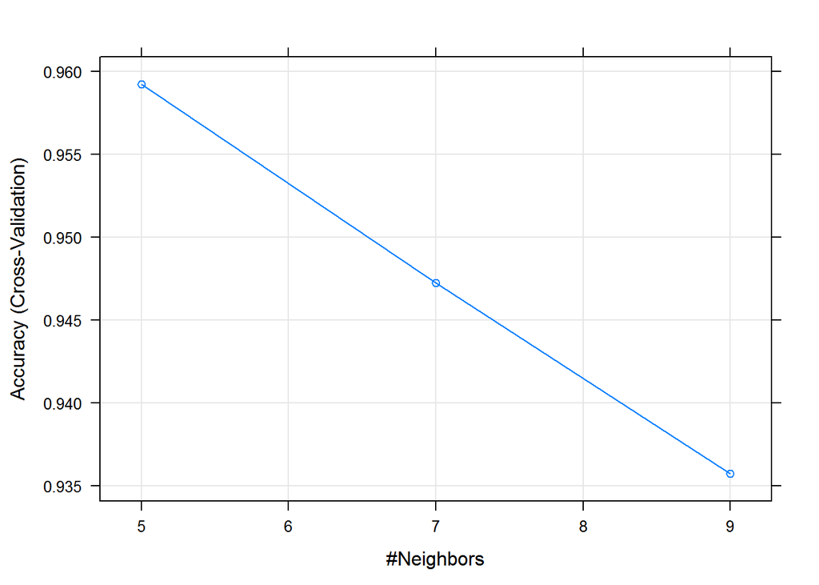

Predict the Testing data set using the K-Nearest Neighbour Model

```r
KNNpred <- predict(KNNmod,testing)
KNNConfMatrix <- confusionMatrix(KNNpred, testing$classe)
KNNConfMatrix
```

```
## Confusion Matrix and Statistics
##
##           Reference
## Prediction    A    B    C    D    E
##          A 1652   35    8    0    1
##          B   11 1073    7    0    9
##          C    6   23  997   35    6
##          D    4    6   11  926    6
##          E    1    2    3    3 1060
##
## Overall Statistics
##
##                Accuracy : 0.9699
##                  95% CI : (0.9652, 0.9741)
##     No Information Rate : 0.2845
##     P-Value [Acc > NIR] : < 2.2e-16
##
##                   Kappa : 0.9619
##  Mcnemar's Test P-Value : 2.334e-07
##
## Statistics by Class:
##
##                      Class: A Class: B Class: C Class: D Class: E
## Sensitivity            0.9869   0.9421   0.9717   0.9606   0.9797
## Specificity            0.9896   0.9943   0.9856   0.9945   0.9981
## Pos Pred Value         0.9741   0.9755   0.9344   0.9717   0.9916
## Neg Pred Value         0.9947   0.9862   0.9940   0.9923   0.9954
## Prevalence             0.2845   0.1935   0.1743   0.1638   0.1839
## Detection Rate         0.2807   0.1823   0.1694   0.1573   0.1801
## Detection Prevalence   0.2882   0.1869   0.1813   0.1619   0.1816
## Balanced Accuracy      0.9882   0.9682   0.9787   0.9775   0.9889
```

## Conclusion

The Random Forest model produced the best results with an OOB error rate of 0.68% and Accuracy of 99.44%.  
While the K-Nearest Neighbour model produced an Accuracy of 96.99%.  
The Random Forest model consistently out performed the K-Nearest Neighbour Model in all tunning exercises.

## Generate the predicted answers

Generate the 20 prediction files to submit as answers.

```r
predictedAnswers <- predict(randomForestModel,newdata=pml_testing) # Best predictions
#predictedAnswers <- predict(KNNmod,newdata=pml_testing)
#predictedAnswers
saveRDS(predictedAnswers, file="predictedAnswers.rds")
#predictedAnswers <- readRDS("predictedAnswers.rds")
pml_write_files(predictedAnswers)
```